# Семинар 1. Нормальное распределение / Работа с распределением данных

# Загрузка необходимых библиотек

```r
library(dplyr)
library(matrixStats)
library(ggplot2)
library(GGally)
library(ppcor)
library(Hmisc)
library(corrplot)
library(nortest)
library(stats)
library(cowplot)
library(MASS)
library(gridExtra)
```

# Нормальное распределение (его параметры, как выглядит)

Плотность нормального распределения может быть выражена следующей формулой:

$$f(x) = \frac{1}{\sigma \sqrt{2 \pi}} e^{-\frac{(x - \mu)^2}{2 \sigma^2}}$$

где: - $\mu$ — среднее значение, - $\sigma$ — стандартное отклонение.

# Задание параметров для пяти распределений: среднее и стандартное отклонение

```r
params <- list(
  list(mean = 0, sd = 1),
  list(mean = 2, sd = 0.5),
  list(mean = -1, sd = 2),
  list(mean = 4, sd = 1.5),
  list(mean = 1, sd = 0.8)
)
```

# Генерация значений аргументов для вычисления плотности

```r
x <- seq(-5, 7, length.out = 1000)
```

# Создание датафрейма для хранения значений плотности

```r
density_data <- data.frame()
```

# Расчет плотности для каждого распределения и добавление в датафрейм

```r
for (i in seq_along(params)) {
  mean <- params[[i]]$mean
  sd <- params[[i]]$sd
  density_values <- dnorm(x, mean = mean, sd = sd)
  density_data <- rbind(density_data, data.frame(x, density = density_values, distribution = paste("N(", mean, ", ", sd, ")", sep = "")))
}
```

# Построение графика нормальных распределений

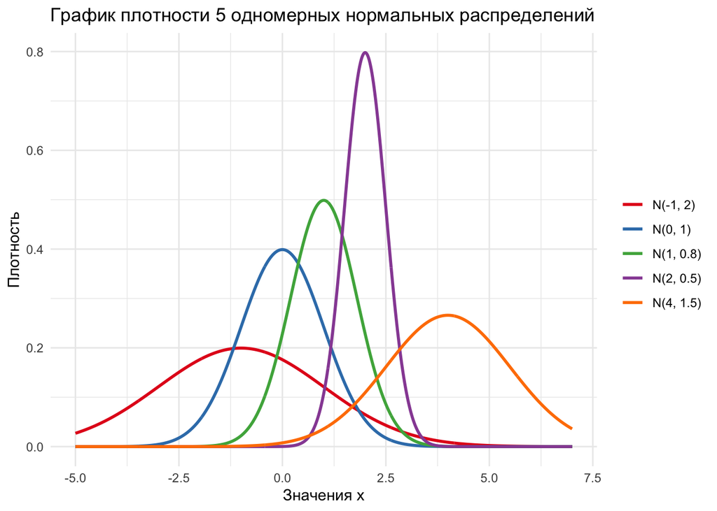

```r
ggplot(density_data, aes(x = x, y = density, color = distribution)) +
  geom_line(size = 1) +
  labs(title = "График плотности 5 одномерных нормальных распределений",
       x = "Значения x",
       y = "Плотность") +
  theme_minimal() +
  scale_color_manual(values = RColorBrewer::brewer.pal(5, "Set1")) +
  theme(legend.title = element_blank())
```

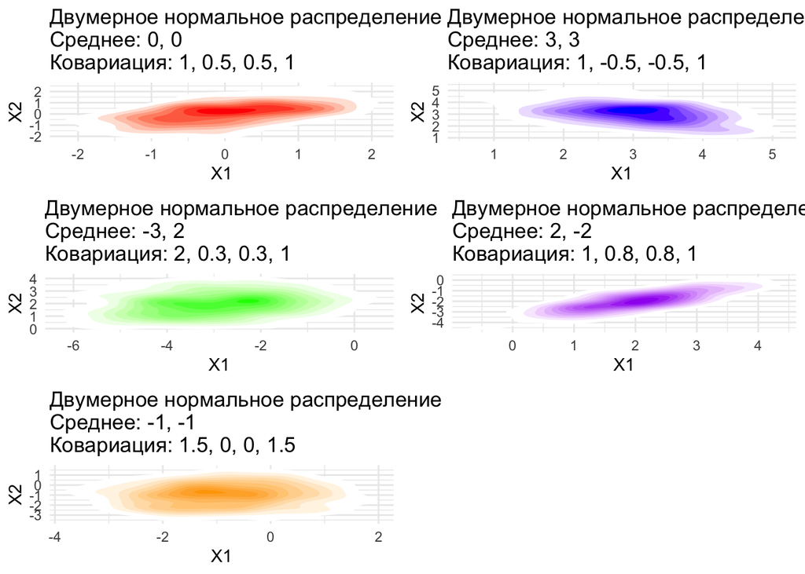

```r
# Функция для генерации и рисования двумерного нормального распределения
plot_2d_normal <- function(mean, covariance, color) {
  # Генерация точек на основе двумерного нормального распределения
  data <- mvrnorm(n = 500, mu = mean, Sigma = covariance)
  data <- as.data.frame(data)
  colnames(data) <- c('X1', 'X2')

  # Создание графика плотности
  p <- ggplot(data, aes(x = X1, y = X2)) +
    stat_density_2d(aes(fill = ..level..), geom = "polygon", contour = TRUE) +
    scale_fill_gradient(low = "white", high = color, guide = "none") +
    labs(title = paste("Двумерное нормальное распределение\nСреднее:",
                       toString(mean),
                       "\nКовариация:", toString(covariance))) +
    theme_minimal()

  return(p)
}

# Задание параметров для 5 разных распределений
params <- list(
  list(mean = c(0, 0), covariance = matrix(c(1, 0.5, 0.5, 1), 2, 2), color = "red"),
  list(mean = c(3, 3), covariance = matrix(c(1, -0.5, -0.5, 1), 2, 2), color = "blue"),
  list(mean = c(-3, 2), covariance = matrix(c(2, 0.3, 0.3, 1), 2, 2), color = "green"),
  list(mean = c(2, -2), covariance = matrix(c(1, 0.8, 0.8, 1), 2, 2), color = "purple"),
  list(mean = c(-1, -1), covariance = matrix(c(1.5, 0, 0, 1.5), 2, 2), color = "orange")
)

# Создание списка графиков
plots <- lapply(params, function(param) {
  plot_2d_normal(param$mean, param$covariance, param$color)
})

# Компоновка всех графиков в одном окне
grid.arrange(grobs = plots, ncol = 2)
```

## Чтение данных

Данные представляют собой 198 записей о параметрах (рост, вес, возраст пол, раса) детей и подростков (от 8 до 18 лет). В начале мы считываем датафрейм:

```r
df <- read.csv(file = "Kids198.csv", header = TRUE, as.is = FALSE)
head(df)
```

|  | X | Height | Weight | Age | Sex | Race |
| --- | --- | --- | --- | --- | --- | --- |
| 1 | 1 | 67.8 | 166 | 210 | 0 | 1 |
| 2 | 2 | 63.0 | 93 | 144 | 1 | 0 |
| 3 | 3 | 50.1 | 54 | 119 | 0 | 0 |
| 4 | 4 | 55.7 | 69 | 130 | 1 | 0 |
| 5 | 5 | 63.2 | 115 | 157 | 0 | 0 |
| 6 | 6 | 48.8 | 52 | 102 | 0 | 0 |

Преобразуем данные в более удобные единицы измерения (кг, см, года):

```r
df$Weight <- df$Weight*0.45
df$Age <- df$Age/12
df$Height <- df$Height * 2.54
df$Sex <- ifelse(df$Sex==1, FALSE, TRUE)    #Берем за true мужской пол
df$Race <- ifelse(df$Race==1, TRUE, FALSE)  #Просто преобразуем int в bool

#Убираем столбец с номером записи
df <- df[-1]
summary(df)
```

```
##      Height          Weight           Age           Sex
##  Min.   :120.4   Min.   :21.15   Min.   : 8.25   Mode :logical
##  1st Qu.:142.4   1st Qu.:34.65   1st Qu.:10.94   FALSE:102
##  Median :154.9   Median :46.35   Median :13.17   TRUE :96
##  Mean   :154.2   Mean   :46.80   Mean   :13.20
##  3rd Qu.:166.5   3rd Qu.:57.60   3rd Qu.:15.40
##  Max.   :184.7   Max.   :89.10   Max.   :18.42
##     Race
##  Mode :logical
##  FALSE:174
##  TRUE :24
##
##
##
```

## Типы имеющихся признаков

#### Рост [См]

ĸоличественный

#### Вес [Кг]

ĸоличественный

#### Возраст [Год]

ĸоличественный

#### Пол [TRUE - муж, FALSE - жен]

Качественный

#### Раса [FALSE - белая, TRUE - цветная]

Качественный

## Martix Plot

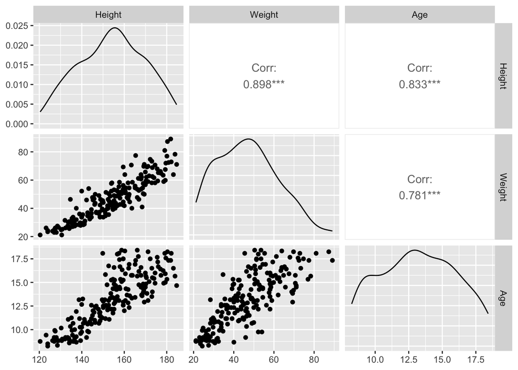

```r
## Matrix plot
library(lattice)
library(ggplot2)
library("GGally")

num_col <- c("Height","Weight","Age")
f <- ggpairs(na.omit(df), columns = num_col,  diag = list(diag = list(continuous = "densityDiag", discrete = "blankDiag", na = "blankDiag")), cardinality_threshold=NULL)
print(f)
```

```r
cor.test(df$Height, df$Weight, method = c("pearson"))
```

```
##
##  Pearson's product-moment correlation
##
## data:  df$Height and df$Weight
## t = 28.579, df = 196, p-value < 2.2e-16
## alternative hypothesis: true correlation is not equal to 0
## 95 percent confidence interval:
##  0.8671860 0.9220187
## sample estimates:
##       cor
## 0.8980355
```

По диагонали матрицы представлены плотности соответствующих признаков, слева относительно диагонали попарные scatter plot, а справа значение коэффицента кореляции.

# Про логнормальное распределение

Функция плотности вероятности (PDF) логнормального распределения задается следующим образом:

$$f(x; \mu, \sigma) = \frac{1}{x \sigma \sqrt{2\pi}} e^{-\frac{(\ln x -
\mu)^2}{2\sigma^2}} \quad \text{для } x > 0$$

Где: - $x$ — переменная, распределенная логнормально. - $\mu$ — математическое ожидание логарифма переменной $X$ (т.е. $Y = \ln(X)$). - $\sigma$ — стандартное отклонение логарифма переменной $X$.

[figure not shown]

```r
# Установка параметров для логнормальных распределений
params <- list(
  list(meanlog = 0, sdlog = 0.1, color = "red"),
  list(meanlog = 0.5, sdlog = 0.2, color = "blue"),
  list(meanlog = 1, sdlog = 0.3, color = "green"),
  list(meanlog = -0.5, sdlog = 0.4, color = "orange"),
  list(meanlog = -1, sdlog = 0.5, color = "purple")
)

# Генерация данных для плотности
x_values <- seq(0, 10, length.out = 1000)
density_data <- data.frame()

for (param in params) {
  densities <- dlnorm(x_values, meanlog = param$meanlog, sdlog = param$sdlog)
  density_data <- rbind(density_data, data.frame(x = x_values, density = densities,
                                                  meanlog = param$meanlog, sdlog = param$sdlog, color = param$color))
}

# Построение графика
ggplot(density_data, aes(x = x, y = density, color = color)) +
  geom_line() +
  labs(title = "Плотность логнормальных распределений",
       x = "x",
       y = "Плотность",
       color = "Параметры") +
  scale_color_manual(values = c("red", "blue", "green", "orange", "purple"),
                     labels = sapply(params, function(param) paste("meanlog =", param$meanlog, "sdlog =", param$sdlog))) +
  theme_minimal() +
  theme(legend.position = "right")
```

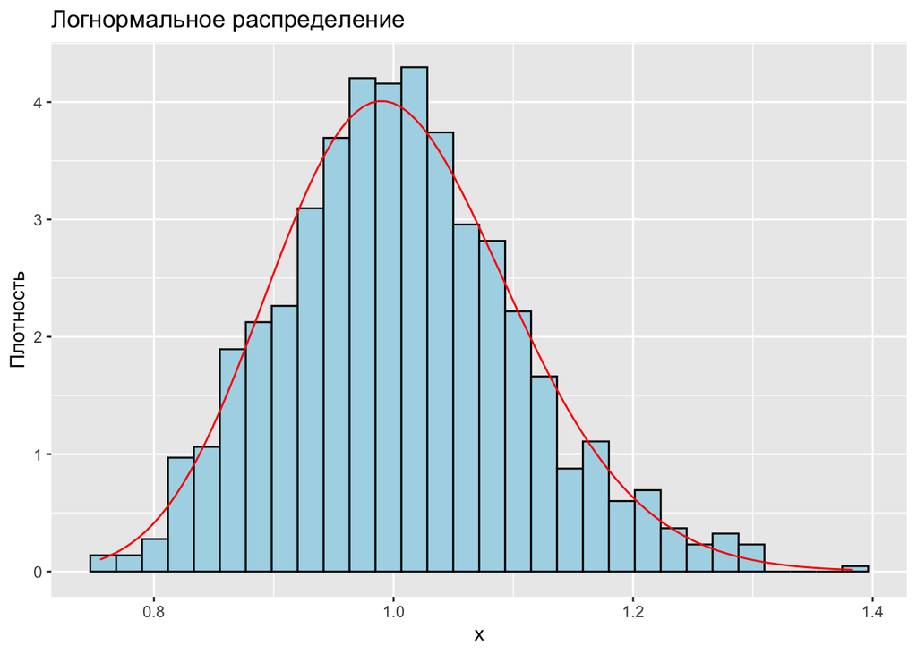

```r
# Устанавливаем параметры для логнормального распределения
meanlog <- 0  # математическое ожидание логарифма
sdlog <- 0.1  # стандартное отклонение логарифма

# Генерируем случайные данные с логнормальным распределением
set.seed(123)  # для воспроизводимости
n <- 1000
lognormal_data <- rlnorm(n, meanlog, sdlog)

# Логарифмируем данные
log_data <- log(lognormal_data)

# Создаем данные для графиков
lognormal_df <- data.frame(value = lognormal_data)
log_df <- data.frame(value = log_data)

# График логнормального распределения
ggplot(lognormal_df, aes(x = value)) +
  geom_histogram(aes(y = ..density..), bins = 30, fill = "lightblue", color = "black") +
  stat_function(fun = dlnorm, args = list(meanlog, sdlog), color = "red") +
  labs(title = "Логнормальное распределение", x = "x", y = "Плотность")
```

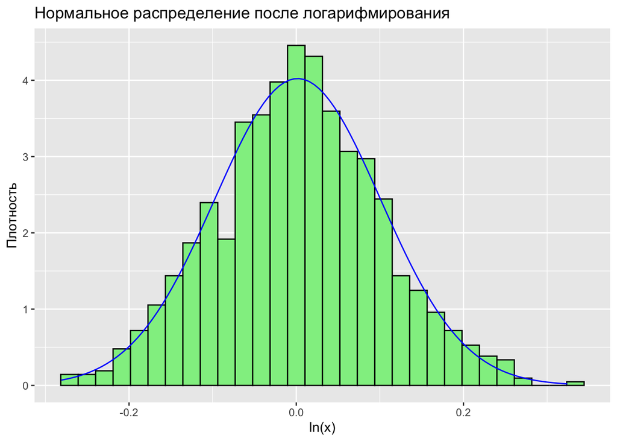

```r
# График нормального распределения (после логарифмирования)
ggplot(log_df, aes(x = value)) +
  geom_histogram(aes(y = ..density..), bins = 30, fill = "lightgreen", color = "black") +
  stat_function(fun = dnorm, args = list(mean = mean(log_data), sd = sd(log_data)), color = "blue") +
  labs(title = "Нормальное распределение после логарифмирования", x = "ln(x)", y = "Плотность")
```

## Логарифмируем вес

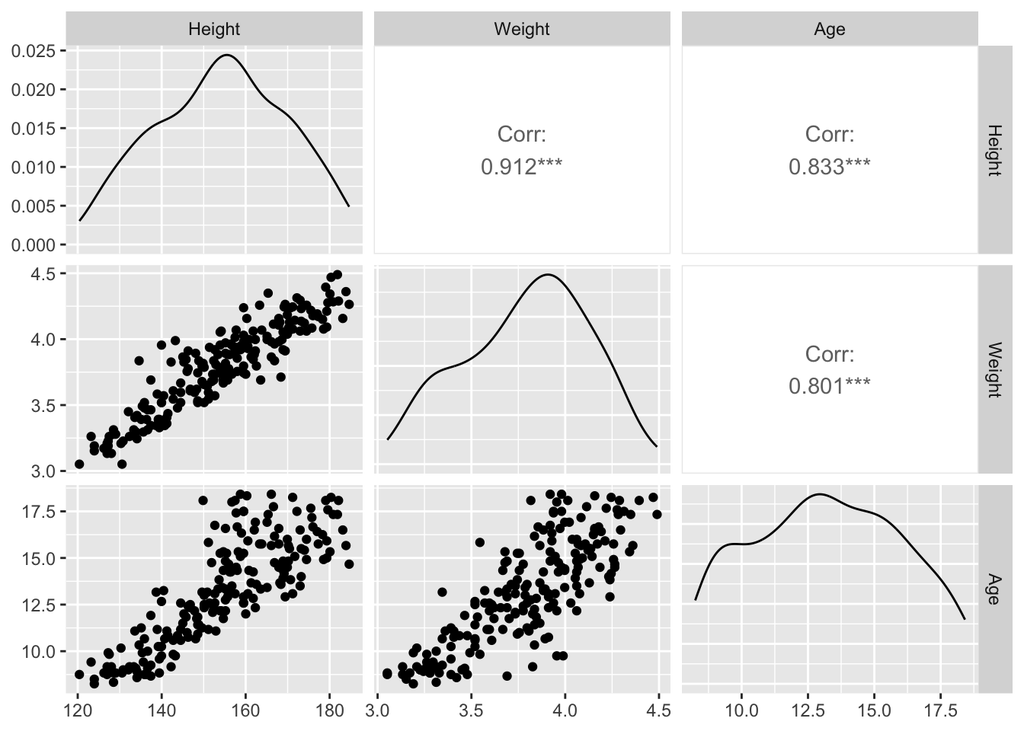

```r
df$Weight <- log(df$Weight)

f <- ggpairs(df, columns = num_col,  diag = list(diag = list(continuous = "densityDiag", discrete = "blankDiag", na = "blankDiag")), cardinality_threshold=NULL)
print(f)
```

Плотности роста, возраста и логарифмированного веса - близки к симметричным, и похожи на нормальное распределение.

## 8. Outliers

Зависимости между признаĸами выглядят линейно, выбросов не наблюдается.

## 9. Неоднородности

Неоднородностей нет.

## 10. Matrix plots и аутлаеры для отдельной группы

Сделаем группировку по полу:

Cиние точки – данные по мужскому полу

Красные точки - данные по женскому полу

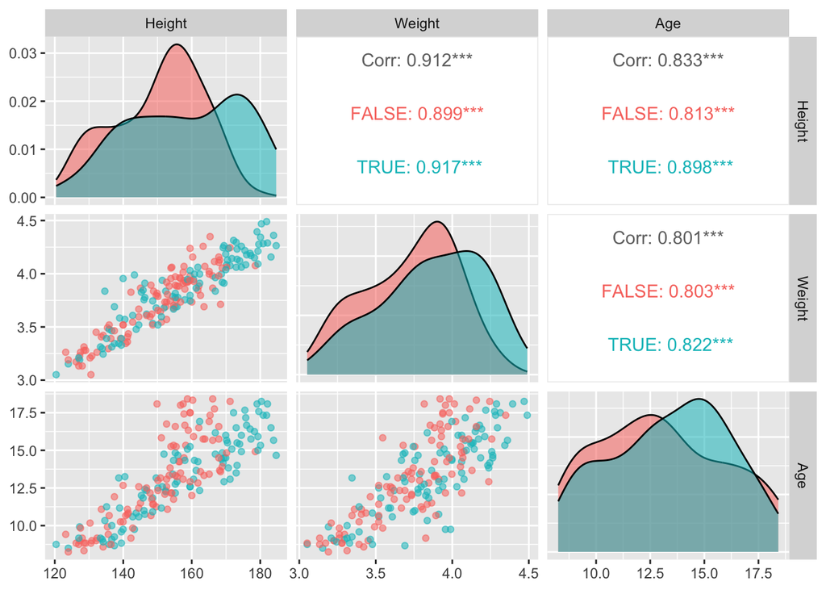

```r
f <- ggpairs(df, columns = num_col,  diag = list(diag = list(continuous = "densityDiag", discrete = "blankDiag", na = "blankDiag")), cardinality_threshold=NULL, mapping = aes(color = df$Sex, alpha = 0.8))
print(f)
```

Видим, что количество наблюдений по каждой группе примерно одинаково. Если посмотреть на плотность возраста, то можно сказать, что в выборке в основном девочки младше мальчиков, этим может быть вызвано различие в плотностях роста и веса.

Красные точки – данные по белой расе

Синие точки - данные по цветным расам

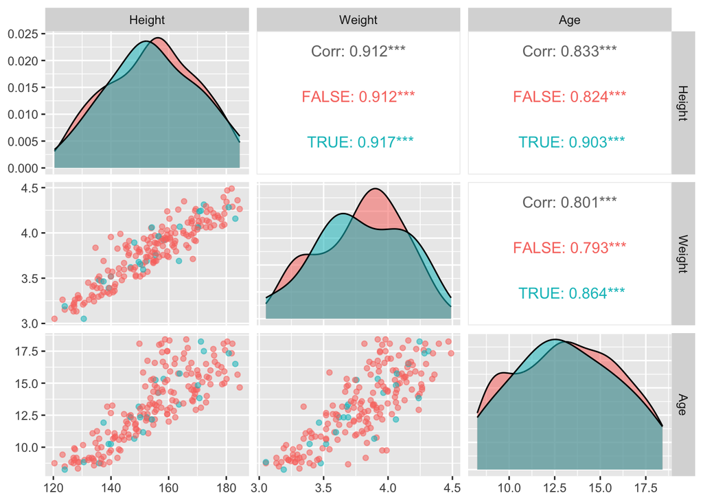

```r
f <- ggpairs(df, columns = num_col,  diag = list(diag = list(continuous = "densityDiag", discrete = "blankDiag", na = "blankDiag")), cardinality_threshold=NULL, mapping = aes(color = df$Race, alpha = 0.8))
print(f)
```

Видим, что количество наблюдений по цветной расе намного меньше, чем по белой. Плотности роста и возраста очень похожи, плотность веса незначительно отличается.

## 11. Descriptive statistics

Посмотрим основные статистики по каждому признаку.

```r
summary(df)
```

```
##      Height          Weight           Age           Sex
##  Min.   :120.4   Min.   :3.052   Min.   : 8.25   Mode :logical
##  1st Qu.:142.4   1st Qu.:3.545   1st Qu.:10.94   FALSE:102
##  Median :154.9   Median :3.836   Median :13.17   TRUE :96
##  Mean   :154.2   Mean   :3.794   Mean   :13.20
##  3rd Qu.:166.5   3rd Qu.:4.054   3rd Qu.:15.40
##  Max.   :184.7   Max.   :4.490   Max.   :18.42
##     Race
##  Mode :logical
##  FALSE:174
##  TRUE :24
##
##
##
```

Также мы можем посчитать коэффициет ассиметрии ($skewness$) и коэффицент эксцесса ($kurtosis$) для каждого признака. В библиотеке $moments$ для этого используются следующие формулы:

Коэффициет ассиметрии рассчитывается по формуле:
$$skewness = \frac{m_3}{\sigma^3},$$
где $m_3$ - центральный эмпирический момент третьего порядка, а $\sigma$ - стандартное выборочное отклонение.

Коэффициет эксцесса рассчитывается по формуле:
$$kurtosis = \frac{m_4}{\sigma^4},$$
где $m_4$ - центральный эмпирический момент четвертого порядка.

С помощью этих коэффицентов можно определить насколько плотность распределения похожа на нормальное (по этим формулам для него $skewness = 0$, а $kurtosis = 3$).

```r
library(moments)
dplyr::summarize(df, across(Height:Age, list(kurtosis = kurtosis, skewness = skewness)))
```

| Height_kurtosis | Height_skewness | Weight_kurtosis | Weight_skewness | Age_kurtosis | Age_skewness |
| --- | --- | --- | --- | --- | --- |
| 2.198014 | -0.08306724 | 2.258501 | -0.2555954 | 1.970522 | 0.02379454 |

Итого получаем:

Рост: скошен влево, ассиметрия незначительна, более пологое относительно нормального

Вес: скошен влево, ассиметрия значительна, более пологое относительно нормального

Возраст: скошен вправо, ассиметрия незначительна, более пологое относительно нормального